# Lecture 9 Predictive Analytics: Data Mining

# Basic Data Mining Techniques in R

#### Preparation

load necessary library and packages for the analysis. install any if necessary ‘car’ stands for Companion for Applied Regression

```r
library(car)
#library(rms) # error here
library(leaps)
library(psych)
library(pca3d)
library(animation)
library(factoextra)
library(caret) # install 'caret' package with 'dependencies=TRUE' turned on
```

# Model Selection and Data Dimensionality Reduction

## Model Selection

### data visualization

a quick way to show all relationships among variables in a dataset (‘iris’ data in R). ‘pairs.panels()’ in ‘psych’ package.

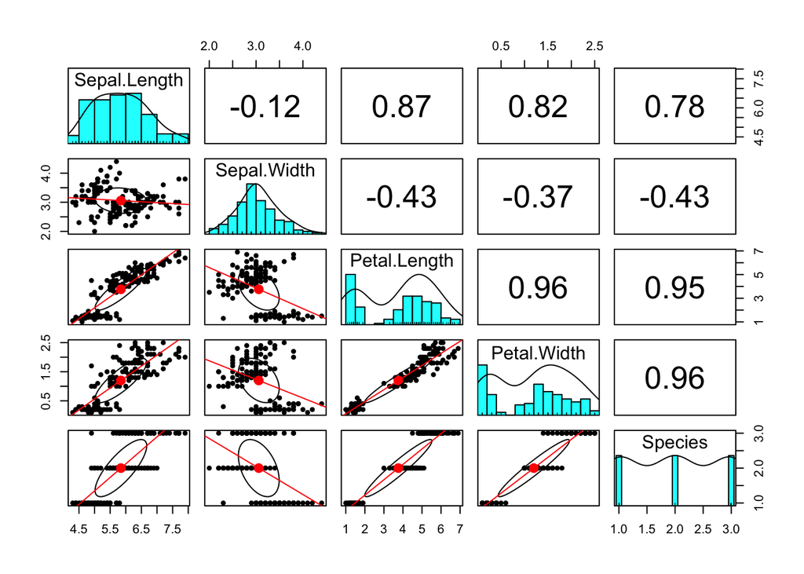

```r
data(iris); pairs.panels(iris, lm=TRUE)
```

### F-test (aka Chow test)

```r
# load the 'mroz.csv' data we used in L7-linear regression. you could read it directly from shared Dropbox link.
mroz_raw = read.csv("https://www.dropbox.com/s/xebreyfhym0nkuy/mroz.csv?dl=1", header = TRUE)
# let's drop some unused variables to include Y and X's that we shall use
mroz = subset(mroz_raw, select = -c(inlf, kidslt6, kidsge6, repwage,
                                    hushrs, husage, huseduc, huswage, mtr,
                                    motheduc, fatheduc, nwifeinc, lwage))

# define your ``unrestricted'' and ``restricted'' models
mod_restricted = wage ~           educ + age + faminc + unem + city + exper + expersq
mod_unrestricted = wage ~ hours + educ + age + faminc + unem + city + exper + expersq
# you need to fit an OLS regression
fit_restricted = lm(mod_restricted, data = mroz)
fit_unrestricted = lm(mod_unrestricted, data = mroz)

## there are at least two ways in R to conduct the F-test (Chow test) on linear combination of regression coeffs.
# approach A: use 'anova()' function on two models under comparison
ftest_hours = anova(fit_restricted, fit_unrestricted)
print(ftest_hours)
```

```
## Analysis of Variance Table
##
## Model 1: wage ~ educ + age + faminc + unem + city + exper + expersq
## Model 2: wage ~ hours + educ + age + faminc + unem + city + exper + expersq
##   Res.Df    RSS Df Sum of Sq      F    Pr(>F)
## 1    745 6413.5
## 2    744 5754.5  1    659.05 85.209 < 2.2e-16 ***
## ---
## Signif. codes:  0 '***' 0.001 '**' 0.01 '*' 0.05 '.' 0.1 ' ' 1
```

### approach B:

use ‘linearHypothesis()’ from ‘car’ package. first, give the unrestricted model and then specify linear combination of coefs you are testing. Here in this case, a simple one, ‘hours = 0’. (‘hours’ means the slope of ‘hours’)

```r
mod_unrestricted = wage ~ hours + educ + age + faminc + unem + city + exper + expersq
fit_unrestricted = lm(mod_unrestricted, data = mroz)
# use 'linearHypothesis()'
linearHypothesis(model = fit_unrestricted, "hours = 0")
```

```
## Linear hypothesis test
##
## Hypothesis:
## hours = 0
##
## Model 1: restricted model
## Model 2: wage ~ hours + educ + age + faminc + unem + city + exper + expersq
##
##   Res.Df    RSS Df Sum of Sq      F    Pr(>F)
## 1    745 6413.5
## 2    744 5754.5  1    659.05 85.209 < 2.2e-16 ***
## ---
## Signif. codes:  0 '***' 0.001 '**' 0.01 '*' 0.05 '.' 0.1 ' ' 1
```

```r
# observation:
# 1. the p-value of F-test is 2.2e-16 which is very samll, suggesting a strong evidence to REJECT the null hypothesis,
#    i.e. H0: "hours = 0" or equivalently in this case, "unrestricted model (with 'hours') is not significantly better than restricted model (without 'hours')
#    in terms of its explanatory power". Therefore, including 'hours' indeed improves the explanatory power of the model to predict our dependent var 'wage'.
# 2. from the F-test outputs, these two are equivalent, yielding a F-statistic = 85.209

## note that the Chow test can test simultaneously 'hours = 0' AND 'educ = 0'
linearHypothesis(model = fit_unrestricted, c("hours = 0", "educ = 0"))
```

```
## Linear hypothesis test
##
## Hypothesis:
## hours = 0
## educ = 0
##
## Model 1: restricted model
## Model 2: wage ~ hours + educ + age + faminc + unem + city + exper + expersq
##
##   Res.Df    RSS Df Sum of Sq      F    Pr(>F)
## 1    746 6745.4
## 2    744 5754.5  2     990.9 64.057 < 2.2e-16 ***
## ---
## Signif. codes:  0 '***' 0.001 '**' 0.01 '*' 0.05 '.' 0.1 ' ' 1
```

```r
# observation: the small p - value = 2.2e-16 shows strong evidence that we can REJECT the null hypothesis, i.e.
# "unrestricted model (with 'hours' and 'educ') is not significantly better than restricted model (without 'hours' and 'educ')
#  in terms of its explanatory power".
```

## Stepwise Model Selection

### Backward Stepwise Selection:

starting from `kitchen sink'' model and excluding the`weakest’’ predictor one-by-one until end point reaches.  
we can use ‘drop1()’ function to manually exclude predictor with smallest partial F-test statistic start with our ``kitchen-sink’’ model, formula ‘wage ~ .’ means regress ‘wage’ on everything else in the data set. We shall keep excluding predictors until all p-values in partial F-test is smaller than 0.1 (our end point of selection rule).

```r
fit_full = lm(wage ~ ., mroz)
drop1(fit_full, test = 'F')
```

```
## Single term deletions
##
## Model:
## wage ~ hours + age + educ + faminc + unem + city + exper + expersq
##         Df Sum of Sq    RSS    AIC F value    Pr(>F)
## <none>               5754.5 1549.3
## hours    1    659.05 6413.5 1629.0 85.2091 < 2.2e-16 ***
## age      1      6.30 5760.8 1548.2  0.8147  0.367034
## educ     1    342.66 6097.2 1590.9 44.3030 5.459e-11 ***
## faminc   1     63.40 5817.9 1555.6  8.1969  0.004314 **
## unem     1      0.29 5754.8 1547.4  0.0370  0.847419
## city     1      0.67 5755.2 1547.4  0.0869  0.768214
## exper    1     44.57 5799.1 1553.2  5.7623  0.016618 *
## expersq  1     12.84 5767.3 1549.0  1.6604  0.197954
## ---
## Signif. codes:  0 '***' 0.001 '**' 0.01 '*' 0.05 '.' 0.1 ' ' 1
```

```r
# observation: 'unem' has the lowest F-stat = 0.037, drop it. So our ``updated'' model is 'wage ~ . -unem'; use 'update()' function
drop1(update(fit_full, ~ . -unem), test = 'F')
```

```
## Single term deletions
##
## Model:
## wage ~ hours + age + educ + faminc + city + exper + expersq
##         Df Sum of Sq    RSS    AIC F value    Pr(>F)
## <none>               5754.8 1547.4
## hours    1    663.76 6418.5 1627.6 85.9288 < 2.2e-16 ***
## age      1      6.54 5761.3 1546.2  0.8465  0.357838
## educ     1    342.51 6097.3 1588.9 44.3406 5.357e-11 ***
## faminc   1     63.36 5818.1 1553.6  8.2018  0.004302 **
## city     1      0.56 5755.3 1545.5  0.0720  0.788458
## exper    1     44.28 5799.1 1551.2  5.7327  0.016898 *
## expersq  1     12.60 5767.4 1547.0  1.6315  0.201899
## ---
## Signif. codes:  0 '***' 0.001 '**' 0.01 '*' 0.05 '.' 0.1 ' ' 1
```

```r
# observation: now 'city' has the lowest F-stat = 0.0720, drop it. So our ``updated'' model is 'wage ~ . -unem -city';
drop1(update(fit_full, ~ . -unem -city), test = 'F')
```

```
## Single term deletions
##
## Model:
## wage ~ hours + age + educ + faminc + exper + expersq
##         Df Sum of Sq    RSS    AIC F value    Pr(>F)
## <none>               5755.3 1545.5
## hours    1    663.74 6419.1 1625.7 86.0328 < 2.2e-16 ***
## age      1      6.22 5761.6 1544.3  0.8068  0.369364
## educ     1    347.84 6103.2 1587.7 45.0862 3.737e-11 ***
## faminc   1     68.33 5823.7 1552.3  8.8564  0.003015 **
## exper    1     45.15 5800.5 1549.3  5.8519  0.015799 *
## expersq  1     13.06 5768.4 1545.2  1.6923  0.193695
## ---
## Signif. codes:  0 '***' 0.001 '**' 0.01 '*' 0.05 '.' 0.1 ' ' 1
```

```r
# observation: now 'age' has the lowest F-stat, drop it. So our ``updated'' model is 'wage ~ . -unem -city -age';
drop1(update(fit_full, ~ . -unem -city -age), test = 'F')
```

```
## Single term deletions
##
## Model:
## wage ~ hours + educ + faminc + exper + expersq
##         Df Sum of Sq    RSS    AIC F value    Pr(>F)
## <none>               5761.6 1544.3
## hours    1    713.62 6475.2 1630.2 92.5226 < 2.2e-16 ***
## educ     1    375.37 6136.9 1589.8 48.6682 6.687e-12 ***
## faminc   1     63.43 5825.0 1550.5  8.2245  0.004249 **
## exper    1     45.12 5806.7 1548.2  5.8503  0.015812 *
## expersq  1     16.84 5778.4 1544.5  2.1833  0.139933
## ---
## Signif. codes:  0 '***' 0.001 '**' 0.01 '*' 0.05 '.' 0.1 ' ' 1
```

```r
# observation: now 'expersq' has the lowest F-stat, drop it. So our ``updated'' model is 'wage ~ . -unem -city -expersq';
drop1(update(fit_full, ~ . -unem -city -age -expersq), test = 'F')
```

```
## Single term deletions
##
## Model:
## wage ~ hours + educ + faminc + exper
##        Df Sum of Sq    RSS    AIC F value    Pr(>F)
## <none>              5778.4 1544.5
## hours   1    756.07 6534.5 1635.1 97.8709 < 2.2e-16 ***
## educ    1    394.59 6173.0 1592.2 51.0789 2.111e-12 ***
## faminc  1     62.64 5841.0 1550.6  8.1081  0.004528 **
## exper   1     62.88 5841.3 1550.6  8.1392  0.004452 **
## ---
## Signif. codes:  0 '***' 0.001 '**' 0.01 '*' 0.05 '.' 0.1 ' ' 1
```

```r
# observation: All predictors have smaller than 0.1 p-values in their partial F-test. DONE.
#              Final backward selected model: 'wage ~ hours + educ + faminc + exper'.
```

Notes:  
Drop the variables that affect RSS/AIC the least one by one until the variables left are only the ones that significantly affect RSS.  
(Done by comparing the least variance between and each variable RSS)

### Forward Stepwise Selection:

starting from intercept only and including the ``strongest’’ predictor one-by-one until end point reaches.  
We can use ‘add1()’ function to manually include predictor with largest partial F-test statistic among potential predictors (searching ‘scope()’) until all remaining predictors await to be added have p-value all greater than 0.1 in partial F-test (our end point for forward selection)

```r
fit_intercept = lm(wage ~ 1, mroz)
add1(fit_intercept, scope = ~ hours + age + educ + faminc + unem + city + exper + expersq, test = 'F')
```

```
## Single term additions
##
## Model:
## wage ~ 1
##         Df Sum of Sq    RSS    AIC F value    Pr(>F)
## <none>               7903.1 1772.3
## hours    1   1413.72 6489.4 1625.9 163.607 < 2.2e-16 ***
## age      1      9.44 7893.7 1773.4   0.898   0.34362
## educ     1    801.10 7102.0 1693.8  84.712 < 2.2e-16 ***
## faminc   1    422.36 7480.8 1732.9  42.401 1.360e-10 ***
## unem     1      0.00 7903.1 1774.3   0.000   0.99721
## city     1     33.81 7869.3 1771.0   3.227   0.07283 .
## exper    1    496.24 7406.9 1725.4  50.315 3.030e-12 ***
## expersq  1    294.80 7608.3 1745.6  29.100 9.221e-08 ***
## ---
## Signif. codes:  0 '***' 0.001 '**' 0.01 '*' 0.05 '.' 0.1 ' ' 1
```

```r
# observation: 'hours' has the largest F-test statistics = 163.607, add it. Our ``updated'' model is 'wage ~ +hours'; use 'update()' function
add1(update(fit_intercept, ~ . +hours), scope = ~ hours + age + educ + faminc + unem + city + exper + expersq, test = 'F' )
```

```
## Single term additions
##
## Model:
## wage ~ hours
##         Df Sum of Sq    RSS    AIC F value    Pr(>F)
## <none>               6489.4 1625.9
## age      1      3.34 6486.0 1627.5  0.3865  0.534340
## educ     1    598.16 5891.2 1555.0 76.1502 < 2.2e-16 ***
## faminc   1    231.47 6257.9 1600.5 27.7409 1.814e-07 ***
## unem     1      5.11 6484.3 1627.3  0.5906  0.442440
## city     1     41.29 6448.1 1623.0  4.8024  0.028728 *
## exper    1     59.46 6429.9 1620.9  6.9350  0.008627 **
## expersq  1     23.49 6465.9 1625.1  2.7244  0.099246 .
## ---
## Signif. codes:  0 '***' 0.001 '**' 0.01 '*' 0.05 '.' 0.1 ' ' 1
```

```r
# observation: 'educ' has the largest F-test statistics = 76.15, add it. Our ``updated'' model is 'wage ~ +hours +educ';
add1(update(fit_intercept, ~ . +hours +educ), scope = ~ hours + age + educ + faminc + unem + city + exper + expersq, test = 'F' )
```

```
## Single term additions
##
## Model:
## wage ~ hours + educ
##         Df Sum of Sq    RSS    AIC F value  Pr(>F)
## <none>               5891.2 1555.0
## age      1     1.105 5890.1 1556.9  0.1405 0.70785
## faminc   1    49.958 5841.3 1550.6  6.4058 0.01158 *
## unem     1     0.106 5891.1 1557.0  0.0135 0.90759
## city     1     6.211 5885.0 1556.2  0.7905 0.37423
## exper    1    50.198 5841.0 1550.6  6.4369 0.01138 *
## expersq  1    26.459 5864.8 1553.7  3.3792 0.06642 .
## ---
## Signif. codes:  0 '***' 0.001 '**' 0.01 '*' 0.05 '.' 0.1 ' ' 1
```

```r
# observation: 'exper' has the largest F-test statistics, add it. Our ``updated'' model is 'wage ~ +hours +educ +exper';
add1(update(fit_intercept, ~ . +hours +educ +exper), scope = ~ hours + age + educ + faminc + unem + city + exper + expersq, test = 'F' )
```

```
## Single term additions
##
## Model:
## wage ~ hours + educ + exper
##         Df Sum of Sq    RSS    AIC F value   Pr(>F)
## <none>               5841.0 1550.6
## age      1     3.330 5837.7 1552.2  0.4267 0.513797
## faminc   1    62.636 5778.4 1544.5  8.1081 0.004528 **
## unem     1     0.013 5841.0 1552.6  0.0017 0.967066
## city     1     5.677 5835.4 1551.9  0.7277 0.393918
## expersq  1    16.041 5825.0 1550.5  2.0598 0.151643
## ---
## Signif. codes:  0 '***' 0.001 '**' 0.01 '*' 0.05 '.' 0.1 ' ' 1
```

```r
# observation: 'faminc' has the largest F-test statistics, add it. Our ``updated'' model is 'wage ~ +hours +educ +exper +faminc';
add1(update(fit_intercept, ~ . +hours +educ +exper +faminc), scope = ~ hours + age + educ + faminc + unem + city + exper + expersq, test = 'F' )
```

```
## Single term additions
##
## Model:
## wage ~ hours + educ + exper + faminc
##         Df Sum of Sq    RSS    AIC F value Pr(>F)
## <none>               5778.4 1544.5
## age      1   10.0079 5768.4 1545.2  1.2960 0.2553
## unem     1    0.0797 5778.3 1546.5  0.0103 0.9192
## city     1    0.5170 5777.9 1546.4  0.0668 0.7961
## expersq  1   16.8399 5761.6 1544.3  2.1833 0.1399
```

```r
# observation: Now, all remaining potential predictors to be added have p-values greater than 0.1 in their partial F-tests, which is specified as our end point.
#              Final forward selected model: 'wage ~ hours + educ + faminc + exper'.
#              Awesome result: backward and forward selection reaches the same conclusion! Note: this is not always the case.
```

## Automating Model Selection based on ‘AIC’ score: using ‘step()’ function.

For large data set which typically has over 100 different variables. Manual selection is not only tedious but impossible task for human being.  
Instead of repeatedly using partial F-test, we can simply select model based on AIC scores (note that OLS also produces AIC score even though we won’t cover it in this module)

### automated backward stepwise model selection: select the model with the lowest AIC score

```r
step(fit_full, direction = 'backward')
```

```
## Start:  AIC=1549.35
## wage ~ hours + age + educ + faminc + unem + city + exper + expersq
##
##           Df Sum of Sq    RSS    AIC
## - unem     1      0.29 5754.8 1547.4
## - city     1      0.67 5755.2 1547.4
## - age      1      6.30 5760.8 1548.2
## - expersq  1     12.84 5767.3 1549.0
## <none>                 5754.5 1549.3
## - exper    1     44.57 5799.1 1553.2
## - faminc   1     63.40 5817.9 1555.6
## - educ     1    342.66 6097.2 1590.9
## - hours    1    659.05 6413.5 1629.0
##
## Step:  AIC=1547.39
## wage ~ hours + age + educ + faminc + city + exper + expersq
##
##           Df Sum of Sq    RSS    AIC
## - city     1      0.56 5755.3 1545.5
## - age      1      6.54 5761.3 1546.2
## - expersq  1     12.60 5767.4 1547.0
## <none>                 5754.8 1547.4
## - exper    1     44.28 5799.1 1551.2
## - faminc   1     63.36 5818.1 1553.6
## - educ     1    342.51 6097.3 1588.9
## - hours    1    663.76 6418.5 1627.6
##
## Step:  AIC=1545.46
## wage ~ hours + age + educ + faminc + exper + expersq
##
##           Df Sum of Sq    RSS    AIC
## - age      1      6.22 5761.6 1544.3
## - expersq  1     13.06 5768.4 1545.2
## <none>                 5755.3 1545.5
## - exper    1     45.15 5800.5 1549.3
## - faminc   1     68.33 5823.7 1552.3
## - educ     1    347.84 6103.2 1587.7
## - hours    1    663.74 6419.1 1625.7
##
## Step:  AIC=1544.28
## wage ~ hours + educ + faminc + exper + expersq
##
##           Df Sum of Sq    RSS    AIC
## <none>                 5761.6 1544.3
## - expersq  1     16.84 5778.4 1544.5
## - exper    1     45.12 5806.7 1548.2
## - faminc   1     63.43 5825.0 1550.5
## - educ     1    375.37 6136.9 1589.8
## - hours    1    713.62 6475.2 1630.2
```

```
##
## Call:
## lm(formula = wage ~ hours + educ + faminc + exper + expersq,
##     data = mroz)
##
## Coefficients:
## (Intercept)        hours         educ       faminc        exper      expersq
##  -3.929e+00    1.253e-03    3.351e-01    2.589e-05    9.147e-02   -1.750e-03
```

```r
# observations:
# 1. "step('backward')" function in each step excludes the top listed predictor which is ranked by AIC (with RSS, i.e. Sum of Squares of Residuals)
#    AIC or RSS here means the AIC score and RSS of the model with full (starting) model minus (thus "-" sign) correpsonding predictor. Recall for RSS and AIC, the lower the better.
# 2. backward "step()"s final selected model is 'wage ~ hours + educ + faminc + exper + expersq', different from our manually selected model (F-test based)
```

#### automated forward stepwise model selection: select the model with the lowest AIC score

```r
step(fit_intercept, scope = ~ hours + age + educ + faminc + unem + city + exper + expersq, direction = 'forward')
```

```
## Start:  AIC=1772.26
## wage ~ 1
##
##           Df Sum of Sq    RSS    AIC
## + hours    1   1413.72 6489.4 1625.9
## + educ     1    801.10 7102.0 1693.8
## + exper    1    496.24 7406.9 1725.4
## + faminc   1    422.36 7480.8 1732.9
## + expersq  1    294.80 7608.3 1745.6
## + city     1     33.81 7869.3 1771.0
## <none>                 7903.1 1772.3
## + age      1      9.44 7893.7 1773.4
## + unem     1      0.00 7903.1 1774.3
##
## Step:  AIC=1625.86
## wage ~ hours
##
##           Df Sum of Sq    RSS    AIC
## + educ     1    598.16 5891.2 1555.0
## + faminc   1    231.47 6257.9 1600.5
## + exper    1     59.46 6429.9 1620.9
## + city     1     41.29 6448.1 1623.0
## + expersq  1     23.49 6465.9 1625.1
## <none>                 6489.4 1625.9
## + unem     1      5.11 6484.3 1627.3
## + age      1      3.34 6486.0 1627.5
##
## Step:  AIC=1555.04
## wage ~ hours + educ
##
##           Df Sum of Sq    RSS    AIC
## + exper    1    50.198 5841.0 1550.6
## + faminc   1    49.958 5841.3 1550.6
## + expersq  1    26.459 5864.8 1553.7
## <none>                 5891.2 1555.0
## + city     1     6.211 5885.0 1556.2
## + age      1     1.105 5890.1 1556.9
## + unem     1     0.106 5891.1 1557.0
##
## Step:  AIC=1550.59
```

[output cut: 13 more lines]

```
##           Df Sum of Sq    RSS    AIC
## + expersq  1   16.8399 5761.6 1544.3
## <none>                 5778.4 1544.5
## + age      1   10.0079 5768.4 1545.2
## + city     1    0.5170 5777.9 1546.4
## + unem     1    0.0797 5778.3 1546.5
##
## Step:  AIC=1544.28
## wage ~ hours + educ + exper + faminc + expersq
##
##        Df Sum of Sq    RSS    AIC
## <none>              5761.6 1544.3
## + age   1    6.2242 5755.3 1545.5
## + unem  1    0.4027 5761.2 1546.2
## + city  1    0.2418 5761.3 1546.2
```

```
##
## Call:
## lm(formula = wage ~ hours + educ + exper + faminc + expersq,
##     data = mroz)
##
## Coefficients:
## (Intercept)        hours         educ        exper       faminc      expersq
##  -3.929e+00    1.253e-03    3.351e-01    9.147e-02    2.589e-05   -1.750e-03
```

```r
# # observations:
# 1. "step('forward')" function in each step includes the top listed predictor (with the lowest AIC) which is ranked by AIC (with RSS, i.e. Sum of Squares of Residuals)
# 2. forward "step()"s final selected model agrees with backward AIC-based 'step()' selection.

## WARNING: it is your call to choose the final model. Not the machine!
```

### Data Dimensionality Reduction: Pincipal Component Analysis (PCA)

Let’s keep using ‘mroz’ data set as our example for PCA, PCA can only work on numeric values. NA, factors, etc, need to be removed.

```r
str(mroz)
```

```
## 'data.frame':    753 obs. of  9 variables:
##  $ hours  : int  1610 1656 1980 456 1568 2032 1440 1020 1458 1600 ...
##  $ age    : int  32 30 35 34 31 54 37 54 48 39 ...
##  $ educ   : int  12 12 12 12 14 12 16 12 12 12 ...
##  $ wage   : num  3.35 1.39 4.55 1.1 4.59 ...
##  $ faminc : int  16310 21800 21040 7300 27300 19495 21152 18900 20405 20425 ...
##  $ unem   : num  5 11 5 5 9.5 7.5 5 5 3 5 ...
##  $ city   : int  0 1 0 0 1 1 0 0 0 0 ...
##  $ exper  : int  14 5 15 6 7 33 11 35 24 21 ...
##  $ expersq: int  196 25 225 36 49 1089 121 1225 576 441 ...
```

```r
mroz = na.omit(mroz)
# excluding our resp
# running a principal component analysis (PCA) using 'prcomp()' function
# 'formula = ~ . -wage -city' in 'prcomp' helps us to removes our response variable 'wage' from the data to compute PCs.
# in addition, 'city' is a binary variable (categorical). conventional PCA is not recommended for data including categorical variables.
# there are many factor analysis techniques incorporating categorical variables though they won't be covered in this modules.
pca_mroz = prcomp(formula = ~ . -wage -city, data = mroz, center = TRUE, scale = TRUE)
# display the output of PCA on 'mroz'
summary(pca_mroz)
```

```
## Importance of components:
##                           PC1    PC2    PC3    PC4    PC5     PC6     PC7
## Standard deviation     1.5265 1.1991 1.0548 0.9358 0.8477 0.68376 0.23993
## Proportion of Variance 0.3329 0.2054 0.1590 0.1251 0.1027 0.06679 0.00822
## Cumulative Proportion  0.3329 0.5383 0.6972 0.8223 0.9250 0.99178 1.00000
```

```r
# examining the variable loadings for first 3 principal components (PCs) which account for 70% variation in the data.
print(pca_mroz$rotation)
```

```
##                  PC1         PC2          PC3         PC4        PC5
## hours   -0.345631569  0.27076466  0.430299112  0.30327930 -0.5754642
## age     -0.321965779 -0.20925604 -0.529626873 -0.51615193 -0.1724162
## educ    -0.049158444  0.66505204 -0.028498736 -0.01160272  0.6263020
## faminc  -0.031249837  0.64363668 -0.177221883 -0.41185578 -0.3952988
## unem     0.001989362  0.13040369 -0.707624998  0.67960115 -0.1358546
## exper   -0.624451877 -0.03808345  0.036487123  0.09664451  0.1778066
## expersq -0.619305778 -0.08877245  0.007336772  0.02551774  0.2013122
##                 PC6          PC7
## hours    0.44239024  0.056757964
## age      0.52461156 -0.026227356
## educ     0.40192344  0.023361383
## faminc  -0.47686975 -0.007523696
## unem    -0.03588021  0.025616508
## exper   -0.24366744 -0.712003537
## expersq -0.28189567  0.698486261
```

```r
# remember that PC is the normalized linear combination of ALL predictors, e.g. PC1 is normalized linear combination of 'hours', ...,'expersq',
# with the coefficient of each predictor as the first column of 'pca_mroz$rotation':
pca_mroz$rotation[,1]
```

```
##        hours          age         educ       faminc         unem        exper
## -0.345631569 -0.321965779 -0.049158444 -0.031249837  0.001989362 -0.624451877
##      expersq
## -0.619305778
```

```r
# ``normalized linear combination'' means that sum of squares of those coefficients add up to one, to make sure of this,
sum(pca_mroz$rotation[,1]^2)
```

```
## [1] 1
```

```r
# let's run a linear regression with top 3 PCs
mroz_pca = mroz
mroz_pca$pc1 = pca_mroz$x[,"PC1"]
mroz_pca$pc2 = pca_mroz$x[,"PC2"]
mroz_pca$pc3 = pca_mroz$x[,"PC3"]
# run a linear regression of 'wage ~ pc1 + pc2 + pc3'
pcafit = lm(wage ~ pc1 + pc2 + pc3, mroz_pca)
summary(pcafit)
```

```
##
## Call:
## lm(formula = wage ~ pc1 + pc2 + pc3, data = mroz_pca)
##
## Residuals:
##     Min      1Q  Median      3Q     Max
## -6.6950 -1.4118 -0.4565  0.7464 23.4747
##
## Coefficients:
##             Estimate Std. Error t value Pr(>|t|)
## (Intercept)  2.37457    0.10262  23.139  < 2e-16 ***
## pc1         -0.60385    0.06727  -8.976  < 2e-16 ***
## pc2          1.02724    0.08564  11.995  < 2e-16 ***
## pc3          0.46880    0.09735   4.816 1.78e-06 ***
## ---
## Signif. codes:  0 '***' 0.001 '**' 0.01 '*' 0.05 '.' 0.1 ' ' 1
##
## Residual standard error: 2.816 on 749 degrees of freedom
## Multiple R-squared:  0.2485, Adjusted R-squared:  0.2455
## F-statistic: 82.54 on 3 and 749 DF,  p-value: < 2.2e-16
```

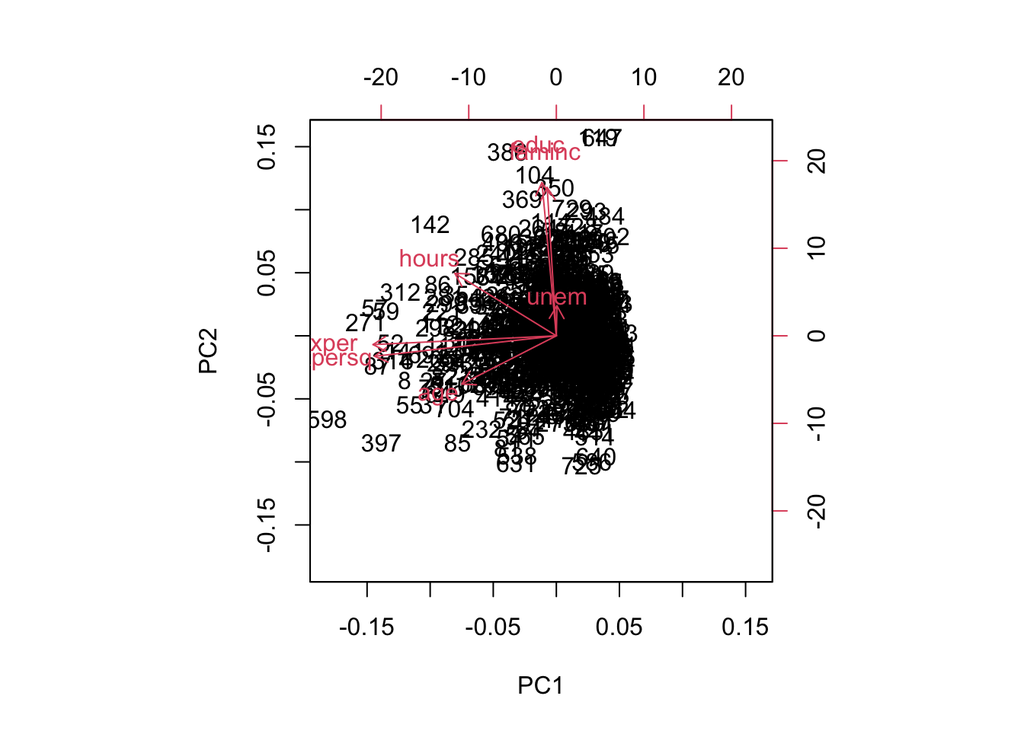

```r
# if you would like to draw the biplot,
biplot(pca_mroz)
```

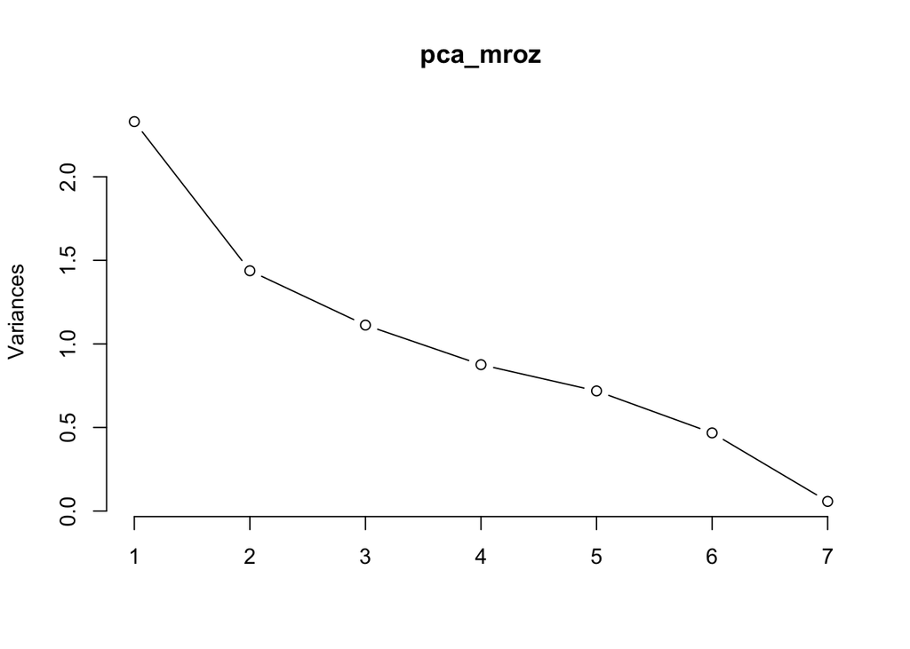

```r
# if you would like to plot the variance explained by each PC
plot(pca_mroz, type = 'lines')
```

```r
# if you would like to see a fancy 3D plot; for Macusers, you need to install xQuartz from xquartz.org.
pca3d(pca_mroz, biplot = TRUE, shape = 'tetrahedron', col = 'blue', axes.color = 'white', bg = 'gray', title = 'Biplot for top 3 PC in 3D space')
```

```
## [1] 0.15211554 0.10375552 0.06494345
## Creating new device
```

```r
# A cool place to visualize the PCA coordinates rotation of the original data set is http://setosa.io/ev/principal-component-analysis/.
```

## Clustering and Classification

### Clustering: k - means (unsupervised)

Use ‘kmeans()’ function to find k-clusters; note: we need to specifiy the number of clusters ‘centers’ (our k).

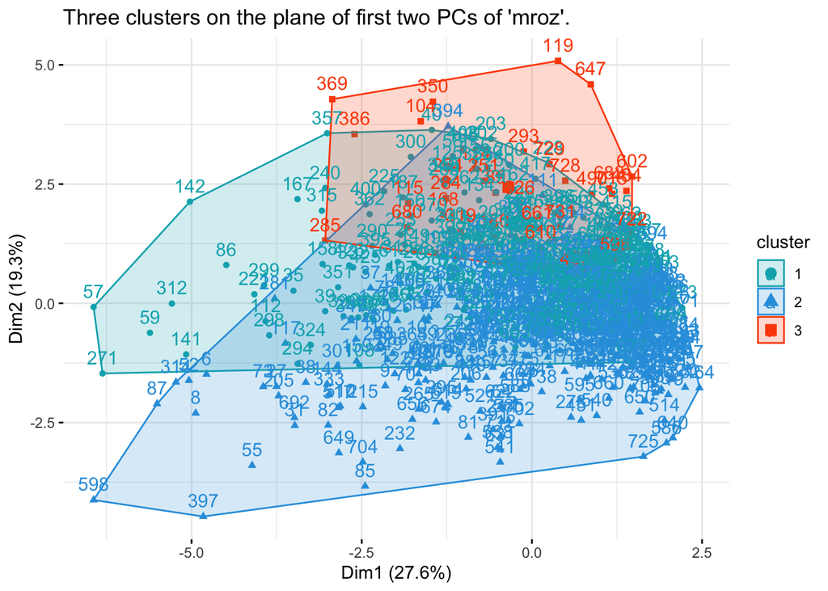

```r
# 'nstart' specifies number of initializations (with starting centeroids randomly placed) of k-means algorithm.
km_mroz = kmeans(mroz, centers =3, nstart = 10)

# k-means plot using 'fviz_cluster' in 'factoextra' package; (#00AFBB, etc. are color codes used in R)
fviz_cluster(km_mroz, data = mroz,
             palette = c("#00AFBB","#2E9FDF", "#FC4E07"),
             ggtheme = theme_minimal(),
             main = "Three clusters on the plane of first two PCs of 'mroz'.")
```

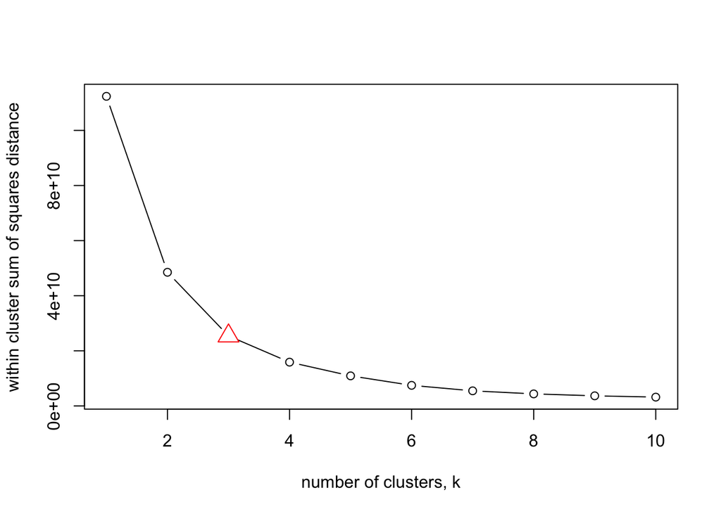

```r
# plot the ``within-cluster sum of squares distance'' as a function of the number of clusters
wss = rep(NA, 10)
for (k in c(1:10)){
  wss[k] = kmeans(mroz, k, nstart = 10)$tot.withinss
}
cexs = rep(1, length(wss))
cexs[3] = 2
pchs = rep(1, length(wss))
pchs[3] = 2
cols = rep('black', length(wss))
cols[3] = 'red'
plot(wss, type = 'b', xlab = 'number of clusters, k', ylab = 'within cluster sum of squares distance', col = cols, pch = pchs, cex = cexs)
```

```r
# when choosing the ``best'' number of clusters, look for the ``elbow''! In this case, either k = 3 or k = 4.
```

## how k-means algorithm works?

use ‘kmeans.ani()’ function in package ‘animation’ package (see https://yihui.org/animation/example/kmeans-ani/ for details)

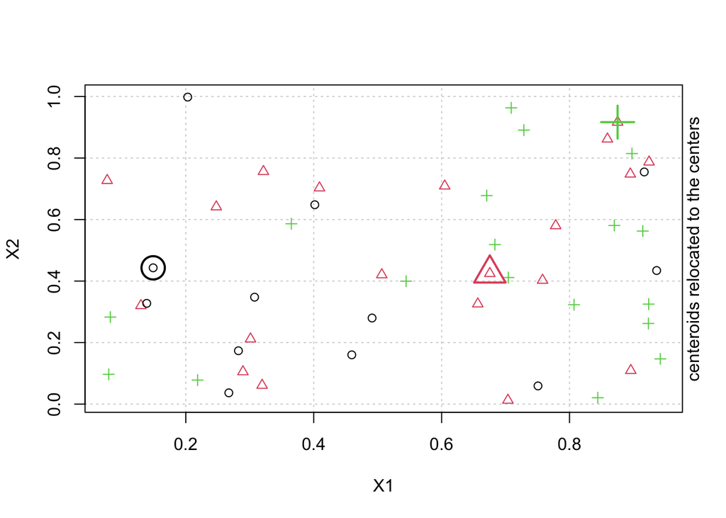

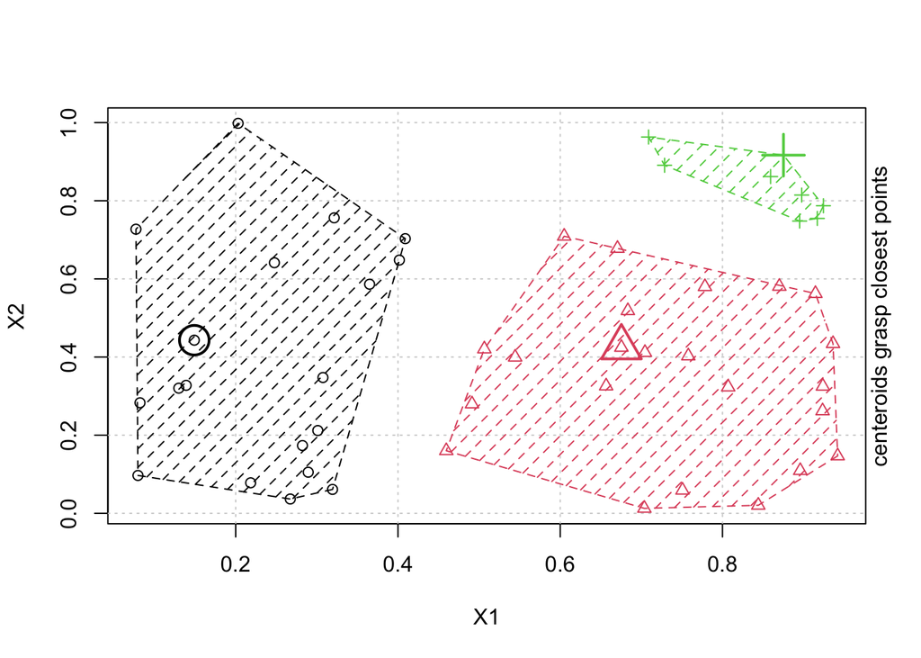

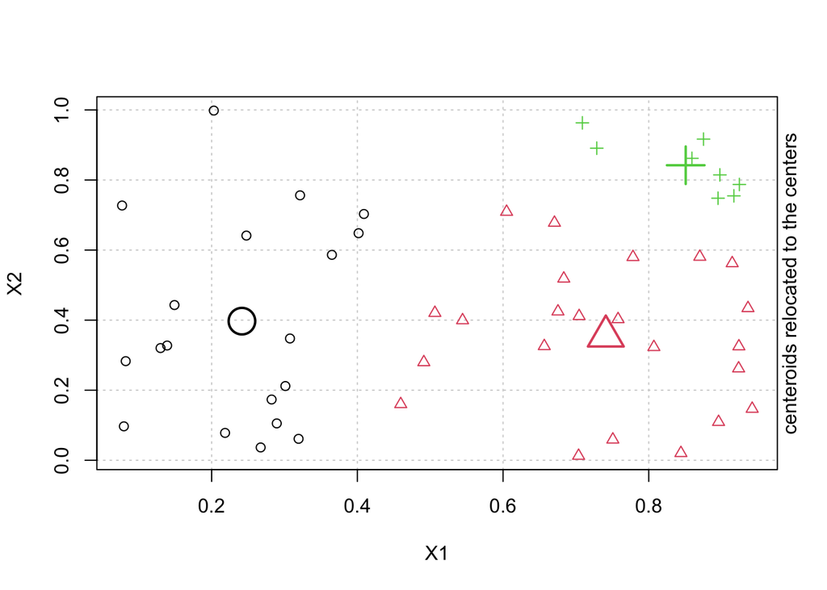

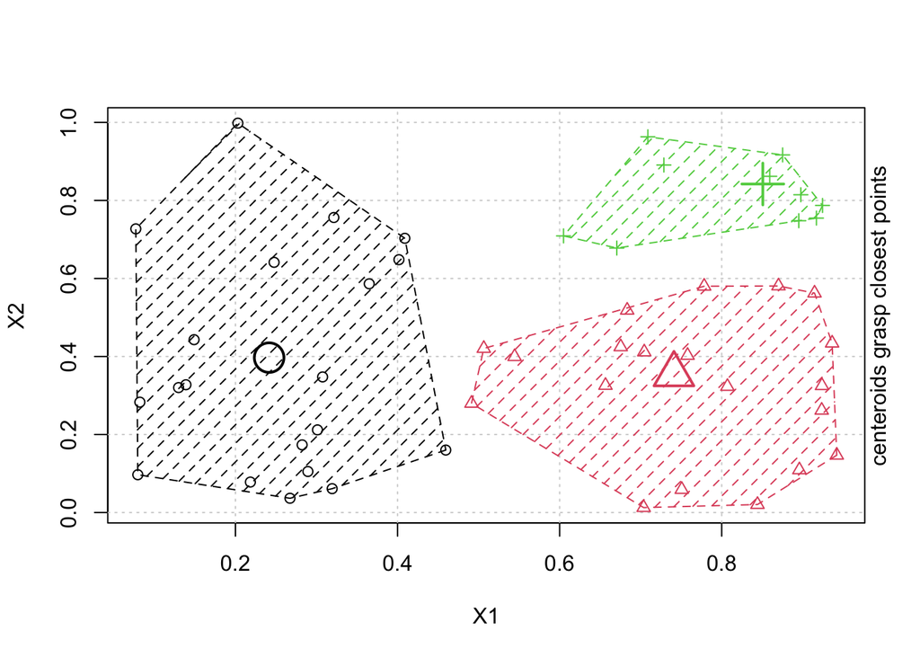

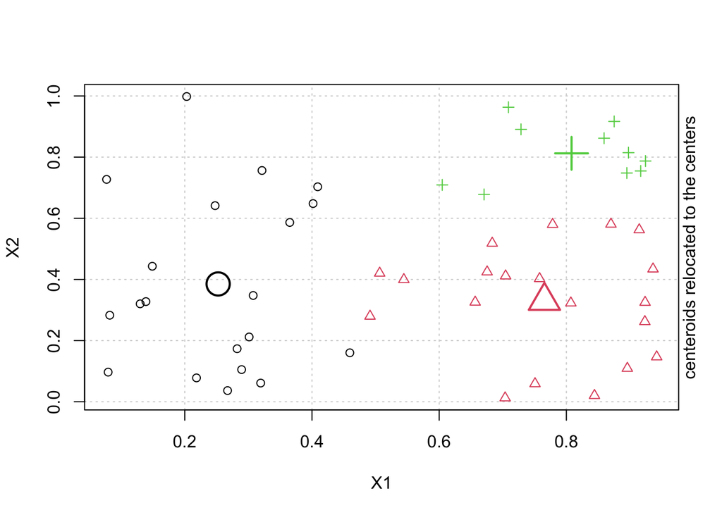

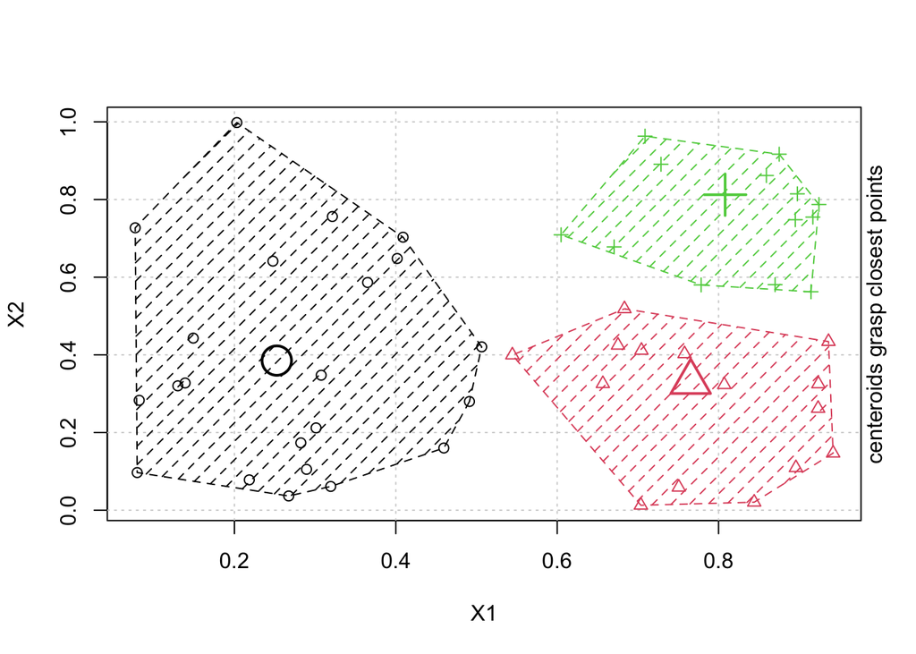

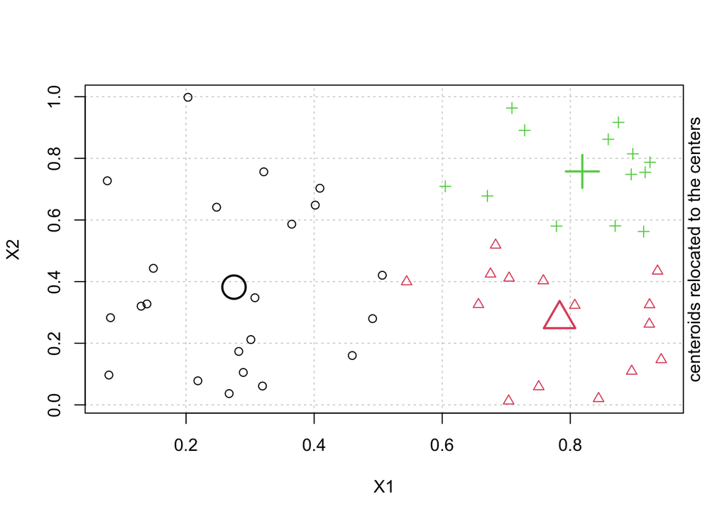

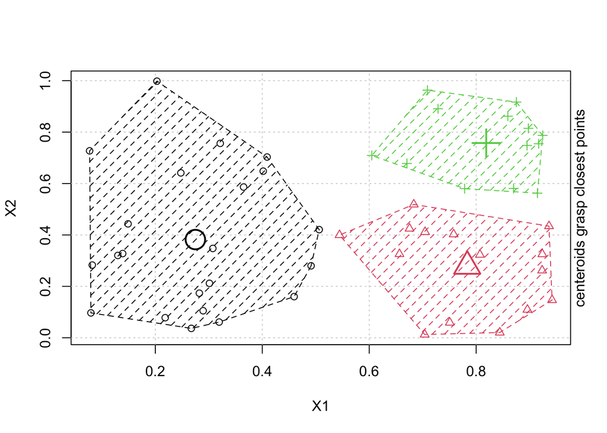

```r
ani.options(interval = 1)
kmeans.ani(x = cbind(X1 = runif(50), X2 = runif(50)), centers = 3,
           hints = c("centeroids relocated to the centers", "centeroids grasp closest points"), pch = 1:3, col = 1:3)
```

### Classification: logistic regression (supervised)

let’s use our familiar example of ‘titanic’.

```r
# read 'titanic.csv' file into data frame object 'titanic'.
titanic_raw = read.csv('https://www.dropbox.com/s/s8onwss8jciv3yi/titanic.csv?dl=1', header = TRUE)
titanic_selected = subset(titanic_raw, select = c("survived", "sex", "age", "sibsp", "parch", "fare", "embarked"))
titanic = na.omit(titanic_selected)
# use 'glm()' with specified parameter 'family = binomial' for logistic regression
fit_surv = glm(survived ~ sex + age + sibsp + parch + fare + embarked, family = binomial, data = titanic, control = list(maxit = 50))
# display the output of logistic regression
summary(fit_surv)
```

```
##
## Call:
## glm(formula = survived ~ sex + age + sibsp + parch + fare + embarked,
##     family = binomial, data = titanic, control = list(maxit = 50))
##
## Deviance Residuals:
##     Min       1Q   Median       3Q      Max
## -2.4061  -0.6454  -0.5270   0.7382   2.3798
##
## Coefficients:
##              Estimate Std. Error z value Pr(>|z|)
## (Intercept)  1.991142   0.335272   5.939 2.87e-09 ***
## sexmale     -2.635345   0.190231 -13.853  < 2e-16 ***
## age         -0.020467   0.007201  -2.842 0.004482 **
## sibsp       -0.394275   0.103822  -3.798 0.000146 ***
## parch       -0.222958   0.114051  -1.955 0.050595 .
## fare         0.014730   0.002849   5.170 2.34e-07 ***
## embarkedQ   -0.679104   0.362057  -1.876 0.060699 .
## embarkedS   -0.504620   0.226659  -2.226 0.025992 *
## ---
## Signif. codes:  0 '***' 0.001 '**' 0.01 '*' 0.05 '.' 0.1 ' ' 1
##
## (Dispersion parameter for binomial family taken to be 1)
##
##     Null deviance: 1182.82  on 888  degrees of freedom
## Residual deviance:  844.15  on 881  degrees of freedom
## AIC: 860.15
##
## Number of Fisher Scoring iterations: 5
```

```r
# Compute the odds ratio and CI's for each coefficient.
exp(cbind(OddsRatio = coef(fit_surv), confint(fit_surv)))
```

```
##              OddsRatio      2.5 %     97.5 %
## (Intercept) 7.32389012 3.84008259 14.3194752
## sexmale     0.07169421 0.04899344  0.1033607
## age         0.97974147 0.96580199  0.9934871
## sibsp       0.67416892 0.54377479  0.8180237
## parch       0.80014881 0.63689642  0.9994883
## fare        1.01483917 1.00946753  1.0208302
## embarkedQ   0.50707121 0.24771886  1.0259723
## embarkedS   0.60373494 0.38750889  0.9433470
```

```r
# now we shall predict the survival probability using out fitted model. note that 'type = response' will compute the probability of survival for us.
predprob_surv = predict(fit_surv, type = 'response')
# let's fix our rule for defining ``survival'': survived = 1 when predicted probability >= 0.5, 0 otherwise; create a new variable 'pred_surv' as predicted survival of our cases in the data.
pred_surv = ifelse(predprob_surv >= 0.5, 1, 0)
```

## Classification (or Confusion) Matrix

```r
# a quick look at how many predicted survival agrees with actual observed survival
sum(pred_surv == titanic$survived)
```

```
## [1] 702
```

```r
# observation: 702 out of 889 successful prediction.

# 'pred_surv' and 'titanic$survived' are still numeric obj, let's convert them to factors.
pred_surv = factor(pred_surv, labels = c('Not Survived', 'Survived'))
titanic$survived = factor(titanic$survived, labels = c('Not Survived', 'Survived'))
# using 'confusionMatrix()' function in R to generate classification or confusion matrix to evaluate our logit classifier.
cm = confusionMatrix(pred_surv, titanic$survived, positive = 'Survived')
# display the classification matrix
print(cm)
```

```
## Confusion Matrix and Statistics
##
##               Reference
## Prediction     Not Survived Survived
##   Not Survived          474      112
##   Survived               75      228
##
##                Accuracy : 0.7897
##                  95% CI : (0.7614, 0.816)
##     No Information Rate : 0.6175
##     P-Value [Acc > NIR] : < 2.2e-16
##
##                   Kappa : 0.5453
##
##  Mcnemar's Test P-Value : 0.008474
##
##             Sensitivity : 0.6706
##             Specificity : 0.8634
##          Pos Pred Value : 0.7525
##          Neg Pred Value : 0.8089
##              Prevalence : 0.3825
##          Detection Rate : 0.2565
##    Detection Prevalence : 0.3408
##       Balanced Accuracy : 0.7670
##
##        'Positive' Class : Survived
##
```